# ggplot

April 24, 2015

## What is ggplot2?

- Is a R graphics package developed by Hadley Wickham
- Implementation of Grammar of graphics - aesthetics (color, shape, size), geoms (points, lines, bars)
- Layers of functions (best of both basic and lattice R plotting systems)
- qplot() , very basic plotting function like plot() and hides complexities
- ggplot(), gives more control

## Basic Components of ggplot

- aesthetic mappings (color, size, data)
- geoms (points, lines, shapes)
- facets (for conditional plots, subsetting)
- stats (bins, quantiles, smoothing)

## Diamond dataset

The diamonds dataset that we will use in this application exercise consists of prices and quality information from about 54,000 diamonds, and is included in the ggplot2 package.

The dataset contains information on prices of diamonds, as well as various attributes of diamonds, some of which are known to influence their price (in 2008 $s): the 4 Cs (carat, cut, color, and clarity) , as well as some physical measurements (depth, table, price, x, y, and z).

```r
library(ggplot2)
data(diamonds)
str(diamonds)
```

```
## 'data.frame':    53940 obs. of  10 variables:
##  $ carat  : num  0.23 0.21 0.23 0.29 0.31 0.24 0.24 0.26 0.22 0.23 ...
##  $ cut    : Ord.factor w/ 5 levels "Fair"<"Good"<..: 5 4 2 4 2 3 3 3 1 3 ...
##  $ color  : Ord.factor w/ 7 levels "D"<"E"<"F"<"G"<..: 2 2 2 6 7 7 6 5 2 5 ...
##  $ clarity: Ord.factor w/ 8 levels "I1"<"SI2"<"SI1"<..: 2 3 5 4 2 6 7 3 4 5 ...
##  $ depth  : num  61.5 59.8 56.9 62.4 63.3 62.8 62.3 61.9 65.1 59.4 ...
##  $ table  : num  55 61 65 58 58 57 57 55 61 61 ...
##  $ price  : int  326 326 327 334 335 336 336 337 337 338 ...
##  $ x      : num  3.95 3.89 4.05 4.2 4.34 3.94 3.95 4.07 3.87 4 ...
##  $ y      : num  3.98 3.84 4.07 4.23 4.35 3.96 3.98 4.11 3.78 4.05 ...
##  $ z      : num  2.43 2.31 2.31 2.63 2.75 2.48 2.47 2.53 2.49 2.39 ...
```

Carat is a unit of mass equal to 200 mg and is used for measuring gemstones and pearl.

```r
summary(diamonds$carat)
```

```
##    Min. 1st Qu.  Median    Mean 3rd Qu.    Max.
##  0.2000  0.4000  0.7000  0.7979  1.0400  5.0100
```

Cut grade is is an objective measure of a diamond’s light performance, or, what we generally think of as sparkle.

```r
levels(diamonds$cut)
```

```
## [1] "Fair"      "Good"      "Very Good" "Premium"   "Ideal"
```

Colour may vary from colourless to light yellow

```r
levels(diamonds$color)
```

```
## [1] "D" "E" "F" "G" "H" "I" "J"
```

Finally Clarity grading

```r
levels(diamonds$clarity)
```

```
## [1] "I1"   "SI2"  "SI1"  "VS2"  "VS1"  "VVS2" "VVS1" "IF"
```

## Histogram

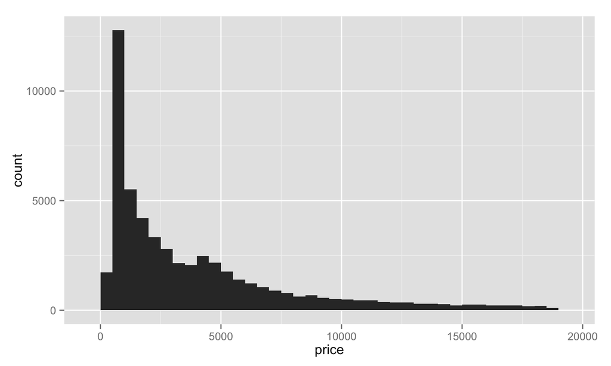

```r
library(ggplot2)
qplot(price, data=diamonds, geom="histogram", binwidth=500)
```

## Barplot

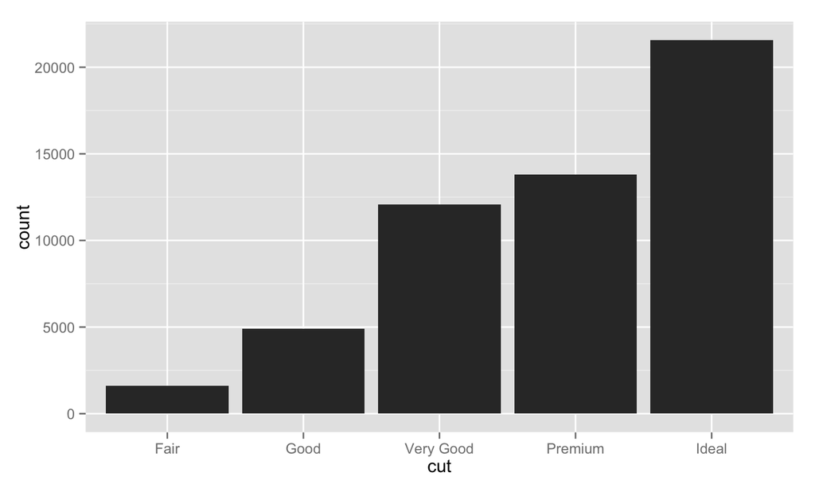

```r
qplot(cut, data=diamonds, geom="bar")
```

## Scatterplot

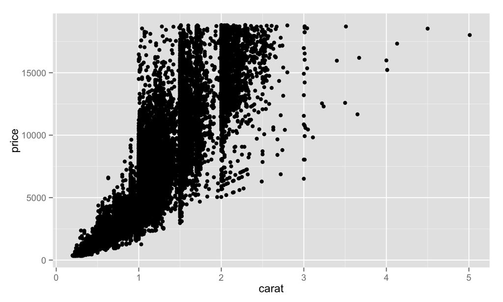

```r
qplot(carat, price, data=diamonds)
```

## Scatterplot

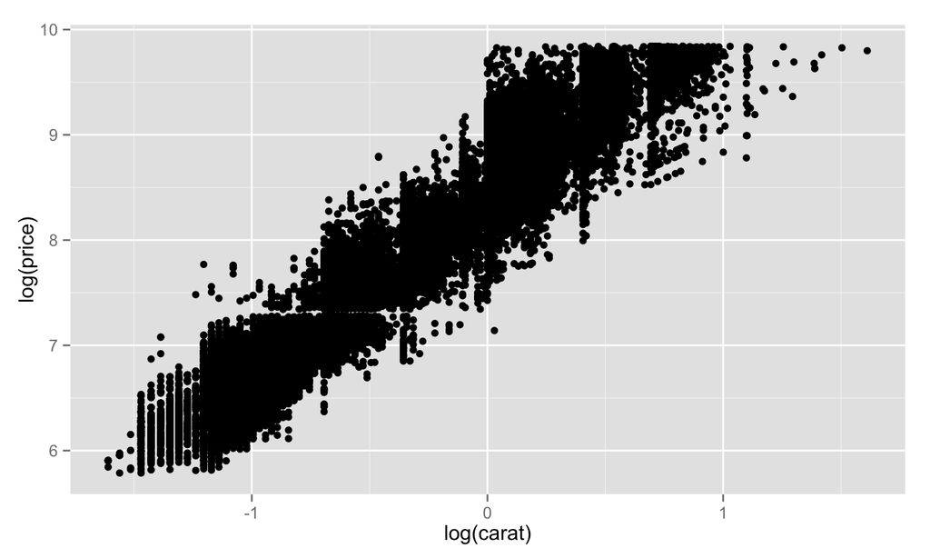

```r
qplot(log(carat), log(price), data=diamonds)
```

## Aesthetics

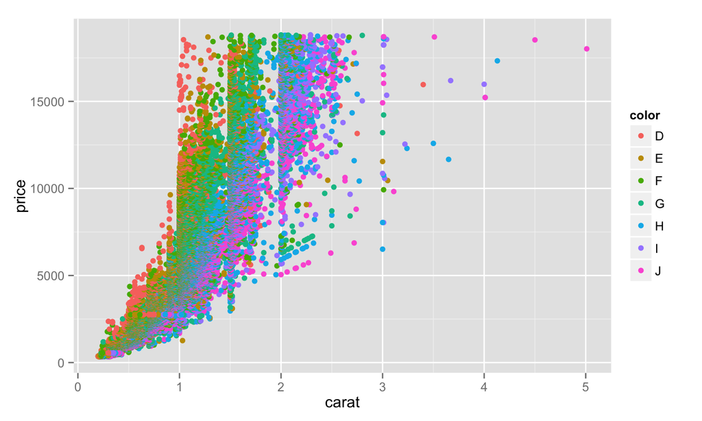

```r
qplot(carat, price, data=diamonds, colour=color)
```

## Aesthetics

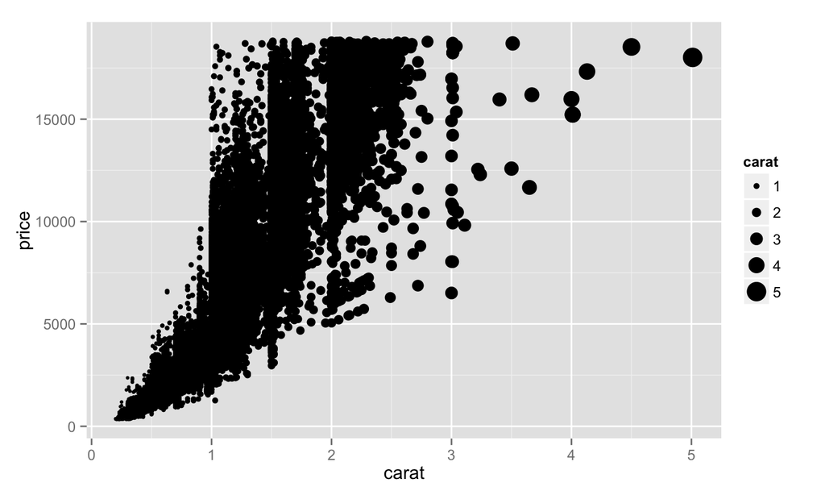

```r
qplot(carat, price, data=diamonds, size=carat)
```

## Aesthetics

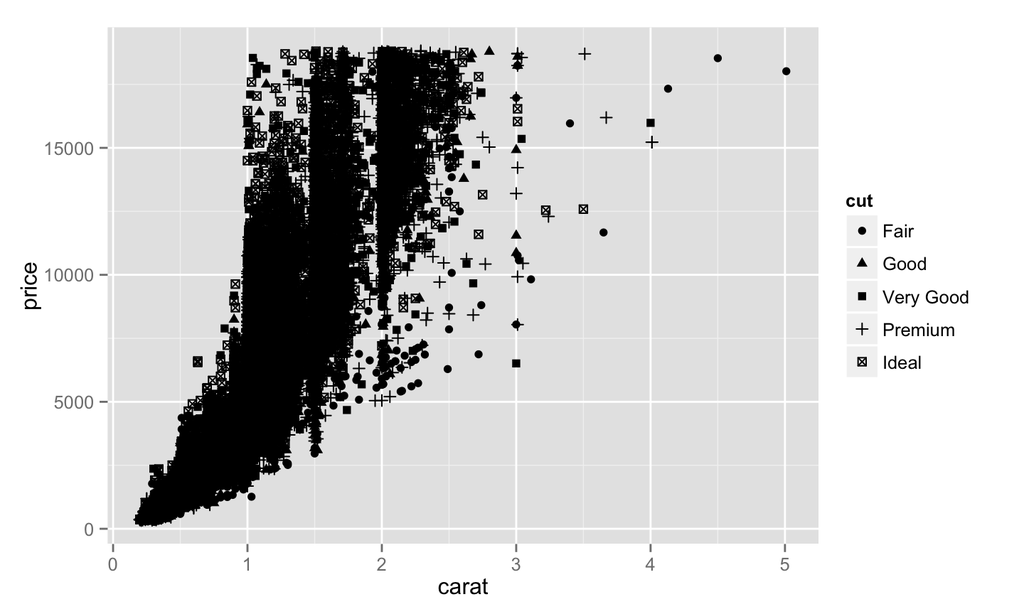

```r
qplot(carat, price, data=diamonds, shape=cut)
```

## Faceting

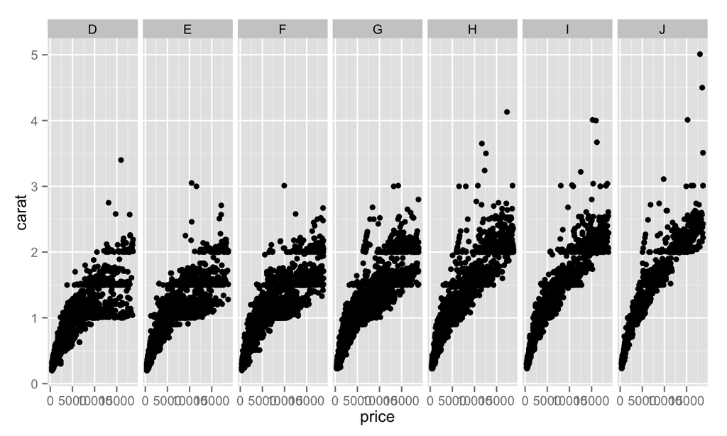

```r
qplot(price, carat, data=diamonds, facets = . ~ color)
```

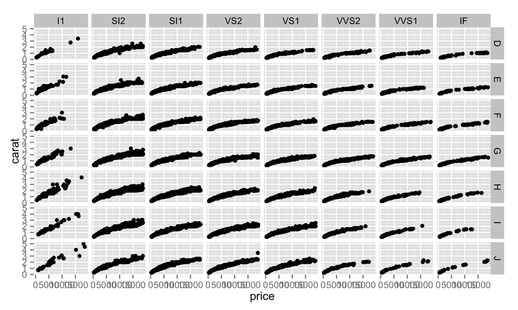

```r
qplot(price, carat, data=diamonds, facets = color ~ clarity)
```